# Practical Machine Learning - Course Project

### Synopsis

This is the course project for the Practical Machine Learning class. The goal of the project is to perform prediction on a data set representing metrics associated to a weigh lifting exercise. The data has been collected during the [Human Activity Recognition](http://groupware.les.inf.puc-rio.br/har.) project, from accelerometers on the belt, forearm, arm, and dumbell of 6 participants, who were asked to perform barbell lifts correctly and incorrectly in 5 different ways. The data set contains the `classe` colunm, representing the outcome to predict. `classe` is a factor variable with 5 levels “A”, “B”, “C”, “D” and “E”.

Six young health participants were asked to perform one set of 10 repetitions of the Unilateral Dumbbell Biceps Curl in five different fashions: exactly according to the specification (Class A), throwing the elbows to the front (Class B), lifting the dumbbell only halfway (Class C), lowering the dumbbell only halfway (Class D) and throwing the hips to the front (Class E).

**Aknowledgments:** Ugulino, W.; Cardador, D.; Vega, K.; Velloso, E.; Milidiu, R.; Fuks, H. Wearable Computing: Accelerometers’ Data Classification of Body Postures and Movements. Proceedings of 21st Brazilian Symposium on Artificial Intelligence. Advances in Artificial Intelligence - SBIA 2012. In: Lecture Notes in Computer Science. , pp. 52-61. Curitiba, PR: Springer Berlin / Heidelberg, 2012. ISBN 978-3-642-34458-9. DOI: 10.1007/978-3-642-34459-6_6.

Read more: http://groupware.les.inf.puc-rio.br/har#ixzz3HBu57iZh

### Getting and Cleaning Data

The training data for this project are available here: https://d396qusza40orc.cloudfront.net/predmachlearn/pml-training.csv. The training data set will be used to build the prediction model.

The test data are available here: https://d396qusza40orc.cloudfront.net/predmachlearn/pml-testing.csv. The test data set will be used in the **Prediction Assignment Submission** section of the Course Project. It is composed of 20 test cases on which the built machine learning algorithm will be applied.

```r
## Create the data directory, in case needed
if (file.exists("./data") == FALSE) {
        dir.create("./data")
}

## Download the "pml-training.csv" file, in case needed
if (file.exists("./data/pml-training.csv") == FALSE) {
        download.file(url = "https://d396qusza40orc.cloudfront.net/predmachlearn/pml-training.csv",
                      destfile = "./data/pml-training.csv", method = "curl", quiet = TRUE)
}

## Read the "pml-training.csv" to a data frame and report its dimensions
pml.training <- read.csv("./data/pml-training.csv")
dim(pml.training)
```

```
## [1] 19622   160
```

### Exploratory Data Analysis

The `pml.training` data set is composed of 160 columns that can be categorized in 6 distinct groups:

1. The first 7 columns `(X, user_name, raw_timestamp_part_1, raw_timestamp_part_2, cvtd_timestamp, new_window, num_window)` represent information of who and when the experiment was conducted.
2. The following 38 columns with the `_belt` suffix `(roll_belt, pitch_belt, yaw_belt, total_accel_belt, kurtosis_roll_belt, kurtosis_picth_belt, ...)`, represent the metrics related to the lumber belt sensor.
3. The following 38 columns with the `_arm` suffix `(roll_arm, pitch_arm, yaw_arm, total_accel_arm, var_accel_arm, avg_roll_arm, ...)`, represent the metrics related to the armband sensor.
4. The following 38 columns with the `_dumbbell` suffix `(roll_dumbbell, pitch_dumbbell, yaw_dumbbell, kurtosis_roll_dumbbell, kurtosis_picth_dumbbell, kurtosis_yaw_dumbbell, ...)`, represent the metrics related to the dumbbell sensor.
5. The following 38 columns with the `_forearm` suffix `(roll_forearm, pitch_forearm, yaw_forearm, kurtosis_roll_forearm, kurtosis_picth_forearm, kurtosis_yaw_forearm, ...)`, represent the metrics related to the glove sensor.
6. The last column `(classe)` represent the outcome, how well the experiment was conducted.

A first approach to identify the model’s predictors is performed through exploratory plots. Since the `classe` outcome is qualitative and not continuous, box plots are used to compare numeric features grouped by classes. The following plot aggregates 4 box plots for the `total_accel_belt`, `total_accel_arm`, `total_accel_dumbbell` and `total_accel_forearm` features:

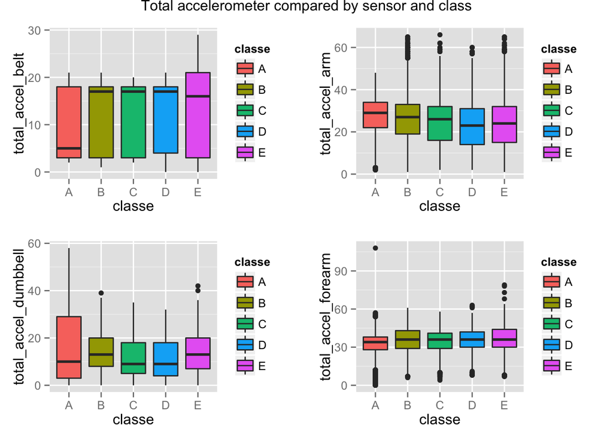

Since the experiment is mainly physical, it is interesting to compare the Euler angles (roll, pitch and yaw) sensors’ metrics, by class, to identify whether these features would be good predictors. To do so, the measures are compounded together by sensor `(roll * pitch * yaw)` and compared by pairs. The following figure shows the results:

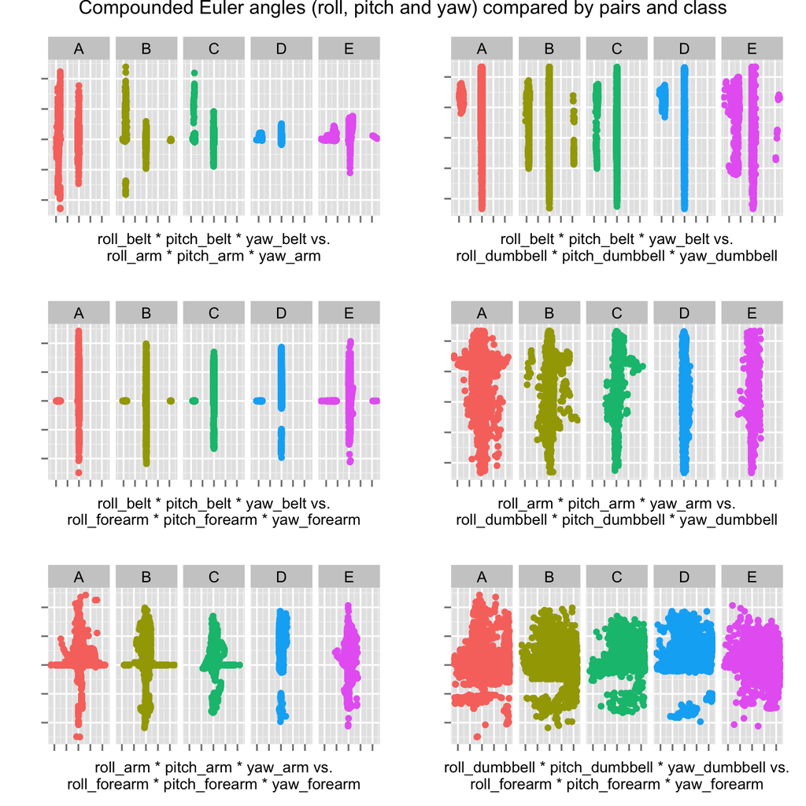

### Predictors Selection

To confirm the empirical exploratory analysis, the data set will be reduced to significant columns, representing significant features that could act as predictors. To do so, the `nearZeroVar()` function of the `caret` package is used to identify then trim the data set. Following that, all columns with at least one NA are also removed from the data set.

```r
## Remove near zero variance predictors from the data set
nzv <- nearZeroVar(x = pml.training, saveMetrics = FALSE)
pml.training <- pml.training[, -nzv]

## Create the nacols function that identifies all columns in a data frame holding at least one NA
nacols <- function(df) {
        colnames(df)[unlist(lapply(df, function(x) any(is.na(x))))]
}

## Remove at-least-one NA columns from the data set
cols <- c(NULL)
for (i in 1:length(nacols(pml.training))) {
        cols <- c(cols, which(colnames(pml.training) == nacols(pml.training)[i]))
}
pml.training <- pml.training[, -cols]

## Report the trimmed data set dimensions
dim(pml.training)
```

```
## [1] 19622    59
```

### Data Partitioning

The `pml.training` data set reduced to 59 significant columns, will now be partitioned to a `training` and `testing` data sets, in order to build and train a prediction model and test it. The provided `pml.testing.csv` composed of 20 test cases will serve as validation in the **Prediction Assignment Submission** section of the Course Project. Based on the exploratory data analysis and consequent to the data set trimming, the Euler angles (roll, pitch and yaw) sensors’ metrics as well as the total accelerometers are used as predictors. The `train()` function of the `caret` package is called with its default values, in order to fit a predictive model with 16 predictors.

```r
## Partition the data set in 60% training and 40% testing and report the dimensions
inTrain <- createDataPartition(y = pml.training$classe, p = 0.6, list = FALSE)
training <- pml.training[inTrain, ]
testing <- pml.training[-inTrain, ]
dim(training); dim(testing)
```

```
## [1] 11776    59
```

```
## [1] 7846   59
```

```r
## Fit a Random Forest model with the selected predictors and default values for train
modFit <- train(classe ~ roll_belt + pitch_belt + yaw_belt + total_accel_belt +
                        roll_arm + pitch_arm + yaw_arm + total_accel_arm +
                        roll_dumbbell + pitch_dumbbell + yaw_dumbbell + total_accel_dumbbell +
                        roll_forearm + pitch_forearm + yaw_forearm + total_accel_forearm,
                method = "rf", data = training)
```

### Model Assessment

```r
modFit
```

[output not shown]

```r
modFit$finalModel
```

```
##
## Call:
##  randomForest(x = x, y = y, mtry = param$mtry)
##                Type of random forest: classification
##                      Number of trees: 500
## No. of variables tried at each split: 9
##
##         OOB estimate of  error rate: 1.34%
## Confusion matrix:
##      A    B    C    D    E class.error
## A 3327   10    3    6    2 0.006272401
## B   18 2226   30    2    3 0.023255814
## C    1   15 2017   21    0 0.018013632
## D    1    3   20 1902    4 0.014507772
## E    0    8    7    4 2146 0.008775982
```

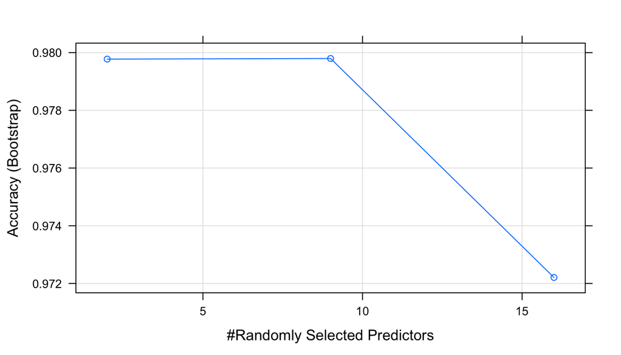

```r
plot.train(modFit)
```

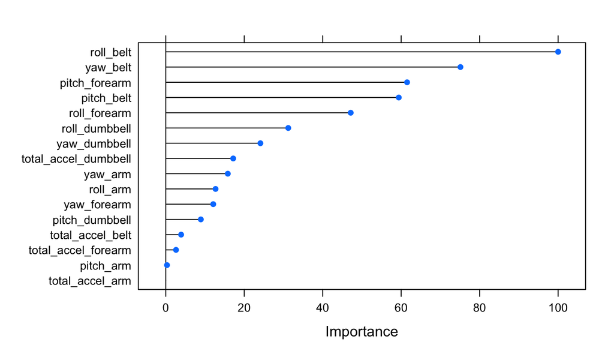

```r
plot(varImp(modFit))
```

The following plot display the Receiver Operating Characteristic (ROC) curve for the 5 different classes with “A” in `red`, “B” in `wheat`, “C” in `green`, “D” in `cyan` and “E” in `magenta`. The ROC curves are plotted in reverse order in order to highlight the plot for the “A” class that overlaps the plot for the “B” class.

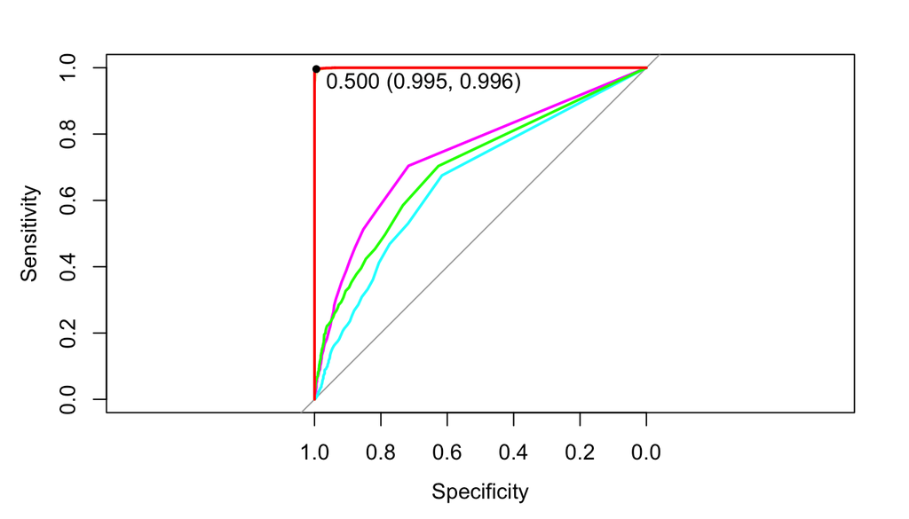

```r
roc5 <- roc(testing$classe, predict(modFit, testing, type = "prob")[, "E"],
            col = "magenta", plot = TRUE)
roc4 <- roc(testing$classe, predict(modFit, testing, type = "prob")[, "D"],
            col = "cyan", plot = TRUE, add = TRUE)
roc3 <- roc(testing$classe, predict(modFit, testing, type = "prob")[, "C"],
            col = "green", plot = TRUE, add = TRUE)
roc2 <- roc(testing$classe, predict(modFit, testing, type = "prob")[, "B"],
            col = "wheat", plot = TRUE, add = TRUE)
roc1 <- roc(testing$classe, predict(modFit, testing, type = "prob")[, "A"],
            col = "red", plot = TRUE, add = TRUE, print.thres = .5)
```

### Data Prediction

```r
confusionMatrix(testing$classe, predict(modFit, testing))
```

```
## Confusion Matrix and Statistics
##
##           Reference
## Prediction    A    B    C    D    E
##          A 2228    4    0    0    0
##          B    9 1483   23    3    0
##          C    0    7 1351   10    0
##          D    1    2   11 1270    2
##          E    0    1    5    2 1434
##
## Overall Statistics
##
##                Accuracy : 0.9898
##                  95% CI : (0.9873, 0.9919)
##     No Information Rate : 0.2852
##     P-Value [Acc > NIR] : < 2.2e-16
##
##                   Kappa : 0.9871
##  Mcnemar's Test P-Value : NA
##
## Statistics by Class:
##
##                      Class: A Class: B Class: C Class: D Class: E
## Sensitivity            0.9955   0.9906   0.9719   0.9883   0.9986
## Specificity            0.9993   0.9945   0.9974   0.9976   0.9988
## Pos Pred Value         0.9982   0.9769   0.9876   0.9876   0.9945
## Neg Pred Value         0.9982   0.9978   0.9940   0.9977   0.9997
## Prevalence             0.2852   0.1908   0.1772   0.1638   0.1830
## Detection Rate         0.2840   0.1890   0.1722   0.1619   0.1828
## Detection Prevalence   0.2845   0.1935   0.1744   0.1639   0.1838
## Balanced Accuracy      0.9974   0.9926   0.9847   0.9929   0.9987
```